WEEK 4 Basic Statistical Learning: Regression Sarah Sachs

[figure not shown]

# In this lecture…

Introduce the idea of statistical learning: learning relationships from observed data. Understand the basic structure of a regression problem. Learn how a simple linear regression model makes predictions. Introduce residuals and the idea of least-squares fitting. Discuss how to assess predictive performance. Introduce training/test data, generalisation, underfitting and overfitting. Extend the ideas to multiple regression and discuss important limitations.

## Part I

# Why regression?

## From estimation to prediction

### So far: estimation

#### Population → Sample → Estimate

Estimate a mean, variance or proportion.

Quantify uncertainty using standard errors and confidence intervals.

### Now: statistical learning

Observed data → Learn relationship → Predict

Use information about an observation to predict an outcome. Ask whether the learned relationship will work on new observations.

Key connection: a fitted regression model is itself an estimate obtained from a sample.

## Motivation

Can we predict delivery time from delivery distance? Can we predict house price from size, location and age? Can we predict electricity demand from temperature and time of day?

These problems share three ingredients:

1. an outcome we care about;
2. information that may help predict it;
3. previous observations from which we can learn.

Recurring example for the lecture: predicting delivery time from delivery distance.

## Do we need distance at all?

### Times only

50

40

30

20

10

Times against distance

𝑌 = 27.5

[figure not shown]

50

40

30

20

10

0

5

10

Distance (km)

15

20

On the left the only sensible answer to “how long will it take?” is the average, 27.5 minutes — the same answer for every delivery. On the right, much of that spread turns out to be distance.

## What is statistical learning?

### Working definition

Statistical learning refers to methods that use observed data to learn relationships between variables.

Two common objectives are:

Prediction: Given new values of those variables, what outcome should we expect? Explanation: How is an outcome associated with one or more variables? A regression model may be used for either purpose, but the two questions are not identical.

## Prediction versus explanation

### Example: delivery time and distance

### Prediction

A new delivery is 10 km away. How long should we expect it to take?

### Explanation

How does delivery time tend to change as distance increases?

Which variables appear to be associated with longer delivery times?

Important: good prediction does not automatically imply a causal explanation.

## Quick check: Part I

A courier wants to know how long a new 10 km delivery will take. Which task is that?

A Explanation C Estimating a population mean

### B Prediction

D Causal inference

## Part II

# Linear regression

## Prediction

What is the delivery time at a distance of 10 km?

10

5

## Prediction

What is the delivery time at a distance of 10 km?

50

40

30

20

10

? 10 km

[figure not shown]

0

5

10

Distance (km)

15

20

## Explanation

How does delivery time depend on distance?

10

5

50

40

30

20

10

## Which line describes these data best?

Option A

0

5

10

15

20

50

40

30

20

10

Option B

[figure not shown]

0

5

10

15

20

50

40

30

20

10

Option C

0

5

10

15

20

## The regression problem

Suppose each observation contains:

an outcome (also called response or target), usually denoted by 𝑌; one or more predictors (also called features or inputs), often denoted by 𝑋.

For our running example:

𝑋 = delivery distance,

𝑌 = delivery time.

Goal: learn a useful relationship between 𝑋 and 𝑌 from a sample of previous deliveries.

## Example dataset

Delivery Distance (km) Time (min)

1 2 3 4 5 6 7 8

2 4 6 9 11 14 17 20

13 16 23 22 27 34 40 41

⋮

Each row is an observation from our sample.

## The simple linear regression model

A simple linear regression prediction can be written as

𝑌 = 𝑏0 + 𝑏1𝑋.

𝑌: observed outcome.

𝑌: predicted outcome (“Y-hat”). 𝑋: predictor.

For our delivery data, the line drawn earlier is

0. intercept.
1. lope.

̂Time = 12 + 1.5 × Distance.

## The regression line, piece by piece

𝑌 = 𝑏0 + 𝑏1𝑋

50

40

30

20

10

becomes ̂Time = 12 + 1.5 × Distance

𝑏0 = 12 +6 min 6 = 1.5 𝑏1 = 4 +4 km 𝑌 − 𝑌 𝑌 = 27 𝑌 = 32

[figure not shown]

0

5

10

Distance (km)

15

20

𝑋 is what we know, 𝑌 is what the line says, 𝑌 is what happened. Two numbers fix the line: where it starts (𝑏0) and how fast it climbs (𝑏1).

## Understanding the intercept

The intercept is 𝑏0 = 12: where the line meets the vertical axis.

The model predicts 12 minutes for a delivery of distance 0 km.

Discussion: a 0 km delivery is not a real delivery — and our data start at 1 km. A coefficient can be perfectly meaningful mathematically and still describe a situation we never observe.

50

40

30

20 10

𝑏0 = 12

[figure not shown]

0

5

10

Distance (km)

15

20

## Understanding the slope

The slope is 𝑏1 = 1.5: the climb of the line per kilometre.

Each additional kilometre adds about 1.5 minutes to the pre dicted delivery time.

So a 12 km delivery is predicted to take about 12 minutes longer than a 4 km one: 1.5 × 8.

50

40

30

20 10

+12 min +8 km

[figure not shown]

0

5

10

Distance (km)

15

20

## Making a prediction

A new delivery is 10 km away:

̂Time = 12 + 1.5(10) = 27.

Go up from 10 on the distance axis to the line, then across to the time axis. Question: Will it take exactly 27 minutes?

50

40

30

20 10

27 min 10 km

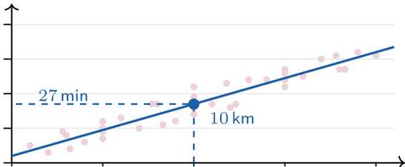

0

5

10

Distance (km)

15

20

50

40

30

20 10

## What the slope tells you: sign and size

𝑏1 > 0: positive

0

5

10

15

our deliveries: further ⇒ longer

𝑏1 < 0: negative

50

40

30

20 10

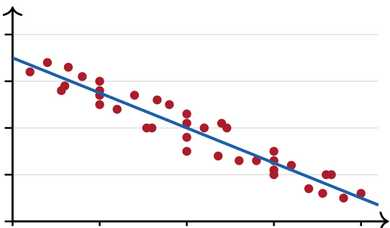

20

𝑏1 ≈ 0: none

0

5

10 15

20

e.g. delivery time against couriers on shift

50

40

30

20

10 0

5

10

15

e.g. time against parcel weight

The sign of 𝑏1 says which way; the size of 𝑏1 says how much per unit. A slope near zero means the predictor carries little information about the outcome — we may as well predict the mean.

20

## Quick check: Part II

In ̂Time = 12 + 1.5 × Distance, what does the 1.5 mean?

A A delivery takes 1.5 minutes C The average delivery takes 1.5 minutes

B Predicted time is 1.5 times the distance

D Each extra kilometre adds about 1.5 minutes to the predicted time

### Part III

# Residuals and fitting

## Prediction is not reality

A fitted model gives a predicted value, not a guarantee. For one of our 10 km deliveries: predicted: 27 minutes; observed: 32 minutes. The model was 5 minutes short. That gap is information.

50

40

30

20 10

predicted 27 observed 32

[figure not shown]

0

5

10

Distance (km)

15

20

## Residuals

For observation 𝑖,

𝑒𝑖 = 𝑌𝑖 − 𝑌𝑖.

For our 10 km delivery,

𝑒 = 32 − 27 = +5 minutes.

𝑒 > 0: observed above the line — the model underpredicted. 𝑒 < 0: observed below the line. 𝑒 ≈ 0: the line got it right.

50

40

30

20 10

𝑒 = +5

[figure not shown]

0

5

10

Distance (km)

15

20

A residual is a vertical gap: observed minus predicted.

## Three residuals, three stories

50

40

30

20

10

𝑒 = +0.5 𝑒 = −4 𝑒 = +5

[figure not shown]

0

5 10

Distance (km)

10 km, 32 min: the model underpredicted by 5 minutes. 12 km, 26 min: the model overpredicted by 4. 5 km, 20 min: the model is almost right.

15

20

50

40

30

20 10

## So which of the three lines was best?

0

50

40

30

20 10

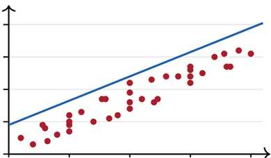

5

10

regression line

∑ 𝑒2 𝑖 = 225

15

20

50

40

30

20

10 0

5

10 15

same slope, too high

∑ 𝑒2 𝑖 = 2042

20

0

5

10

horizontal at 𝑌

∑ 𝑒2 𝑖 = 2609

15

“Best” now has a number attached. Adding up the squared residuals turns the eyeball judgement into a reproducible rule.

20

## Least squares: make the total area small

choose 𝑏0, 𝑏1 to minimise ∑𝑛 𝑒2 𝑖

50

40

30

20

10 0

𝑖=1

[figure not shown]

50

40

30

20 10

5

10

15

the least-squares line: ∑ 𝑒2 𝑖 = 225

20

0

5

10

15

a line 7 minutes too high: ∑ 𝑒2 𝑖 = 2042

20

Each shaded square has side |𝑒𝑖|, so its area is 𝑒2 𝑖 (seven of the 37 are drawn). Squaring stops positive and negative gaps cancelling, and makes one big miss cost more than several small ones.

## Quick check: Part III (a)

A 10 km delivery is predicted to take 27 minutes and actually takes 32. What is the residual, and what did the model do?

A −5; the model overpredicted C +27; the model was right

B +5; the model underpredicted D 5; residuals have no sign

## Quick check: Part III (b) (Challenge)

Suppose our data set is updated with one more delivery at (2 km, 50 min). What happens to the least-squares line?

A Almost nothing: one point out of 38 hardly matters.

C The line becomes almost flat, predicting about 30 minutes everywhere.

B The line moves up, but the slope stays the same.

D The line tilts: it is pulled up at short distances and becomes flatter.

## One unusual delivery, a different line

Add (2 km, 50 min) and refit:

𝑌 = 12 + 1.5𝑋 ⟶ 𝑌 = 15.5 + 1.25𝑋.

One point in 38 moved every prediction. Least squares is fragile to large outliers.

Take away: always plot the data first.

50

40

30

20

10

old: 12 + 1.5𝑋 new: 15.5 + 1.25𝑋 new point 𝑒 = +35

[figure not shown]

0

5

10

Distance (km)

15

20

### Intermezzo

# Correlation ≠ Causation

## A Very heavy Seagul?

## Egg Consumption and the Stock Market?

## Cosmic Influence on Name Preferences?

### Part IV

# Model quality

## How good is the model?

Fitting a line is not the end of the problem. We also need to ask: How large are the prediction errors? Is the model better than a very simple alternative? Will its performance carry over to new observations? These questions shift the focus from fitting to predictive usefulness.

## Intuition

50

40

30

20

10

0

5

10

Distance (km)

15

20

50

40

30

20

10

0

5

10

Distance (km)

15

20

## Compared with what?

50

40

30

20

10

0

5

10

15

20

Baseline: always predict 𝑌 = 27.5 Average Error: 𝑛 1 ∑ |𝑌𝑖 − 𝑌 | = 7.3 min

50

40

30

20

10

0

5

10

15

20

Regression on Distance: 𝑌𝑖 = 12 + 1.5𝑋𝑖 Average Error: 𝑛 1 ∑ |𝑌𝑖 − 𝑌𝑖| = 2.2 min

General principle

[figure not shown]

A model is useful only in relation to a meaningful alternative or baseline.

## The Coefficient of Determination: 𝑅2

The same two pictures as before, now measured with squared error.

50

40

30

20

10

[figure not shown]

0

5

10

15

20

Baseline: always predict 𝑌 = 27.5

Stotal ∶= ∑𝑖(𝑌𝑖 − 𝑌 )2 = 2609

50

40

30

20

10

0

5

10

15

20

Regression on Distance: 𝑌𝑖 = 12 + 1.5𝑋𝑖 Sres ∶= ∑𝑖(𝑌𝑖 − 𝑌𝑖)2 = 225

### The question 𝑅2 answers

What share of the baseline’s squared error does the line remove?

## The Coefficient of Determination: 𝑅2

How to compare Stotal and Sres?

1. Stotal − Sres = 2609 − 225 = 2384?
2. Stotal Sres = 2609 225 = 0.09?

Sres 225 Stotal = 2609 = 0.09

⏟⏟⏟⏟⏟⏟⏟⏟⏟

the share regression still leaves

𝑅2 = 1 − Stotal Sres = 0.91 ⏟⏟⏟⏟⏟⏟⏟⏟⏟

the share regression removes

removed by using regression: 𝑅2 = 91%

the whole bar is the baseline’s squared error, Stotal = 2609

left: 9%

## What 𝑅2 does not tell us

𝑅2 = 0.91 does not mean 91% of deliveries are predicted exactly — ours are still about 2.2 minutes out on average.

It does not establish that distance causes delivery time; it only says the two move together in this sample.

It is measured on the deliveries used to fit the regression line, so it says nothing on its own about new deliveries (Part V).

It is a comparison with one particular baseline. A high 𝑅2 against a weak baseline is not an achievement.

### Rule of thumb

Quote 𝑅2 together with an error in the units of the outcome — “𝑅2 = 0.91, average miss 2.2 minutes” says far more than either number alone.

## Quick check: Part IV

Our delivery model has 𝑅2 = 0.91. Which statement is correct?

A 91% of deliveries are predicted exactly C Distance causes 91% of delivery time

B The model accounts for far more of the variation in delivery time than predicting 𝑌 for everyone D New deliveries will be predicted to within 91%

### Part V

# Generalisation

## Fitting versus predicting

Suppose we fit a model to a dataset and then measure error on exactly the same observations.

Is that a fair test of whether the model has learned something useful?

The model was built using those observations, so performance on them can be overly optimistic.

Analogy: assessing learning using the same questions that were supplied during revision.

## Training and test data

Training set (29 deliveries, red) used to fit the line.

Test set (8 deliveries, blue rings) hidden while fitting, then predicted.

Training deliveries Held-out deliveries

50

40

30

20

(Average Error)2 10 0

2.2 2.3

5

10

Distance (km)

15

20

The blue data points are not used for computing the regression line.

## Generalisation

Key idea

[figure not shown]

Generalisation is the ability of a fitted model to perform well on new observations that were not used to fit it.

For statistical learning, this is usually more important than achieving the smallest possible error on the training sample.

Question: Why might a model fit the training data extremely well but still predict badly on new data?

50

40

30

20

10

## Underfitting and overfitting

Underfitting

0

Useful fit

50

40

30

20

10

[figure not shown]

5

10

15

too simple: ignores distance

Overfitting

20

0

5

10

15

the broad, stable pattern

20

50

40

30

20

10

0

5

10

15

chases every wobble

Connection: samples carry stochastic variability. A flexible model mistakes it for pattern.

20

## Quick check: Part V

A courier company fits a very flexible model. It predicts the 37 deliveries it was trained on almost perfectly, but is 9 minutes out on next week’s deliveries. Is this model

A Overfitting C Extrapolation

B Underfitting D Good generalisation

### Part VI

# Multiple regression

## What if one predictor is not enough?

Our four 10 km deliveries took 24, 26, 29 and 32 minutes. Distance cannot explain that spread — it was the same for all four. But the two slow ones were in heavy

### traffic.

𝑌 = 𝑏0 + 𝑏1𝑋1 + ⋯ + 𝑏𝑝𝑋𝑝.

50

40

30

20

10

0

5

10

Distance (km)

15

20

The deliveries sitting above the line are mostly the blue ones.

## Interpreting multiple regression coefficients

̂Time = 10.6 + 1.5(Distance) + 4.2(Heavy traffic)

50

40

30

20

10

4.2

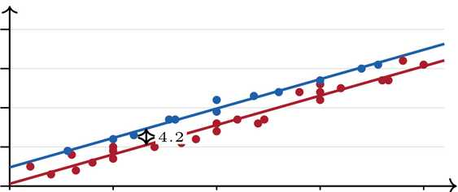

0

5

10

15

20

1.5: holding traffic constant, one more kilometre adds about 1.5 minutes — the slope of both lines. 4.2: holding distance constant, heavy traffic adds about 4.2 minutes — the gap between the lines. Two lines, one slope: that is what “holding the other predictor constant” looks like.

Adding traffic cuts the average error from 2.2 to 1.2 minutes (𝑅2: 0.91 → 0.97).

## Categorical predictors

Predictors need not be numerical — vehicle type might be bicycle, motorbike or van. Pick one as the reference (say van). The other categories then get a coefficient each, read as “compared with a van, at the same distance”. Each category gets its own line, all with the same slope.

50

40

30

20

10

bicycle +7.5 motorbike +3 van (reference)

[figure not shown]

0

5

10

Distance (km)

15

20

(Illustrative numbers, we did not record vehicle type.)

## Quick check: Part VI

With ̂Time = 10.6 + 1.5(Distance) + 4.2(Heavy traffic), two deliveries are both at the same distance of 𝑋 km, one in heavy traffic and one not. How far apart are their predicted times?

A 1.5 minutes

C 4.2 minutes

B Cannot say without knowing the distance

D 18 minutes

### Part VII

# Limits and uncertainty

## Extrapolation

100

75

50

25

0

data here no data here — and no way to check

[figure not shown]

0

10

20

30

Distance (km)

40

50

60

The formula happily returns 12 + 1.5(200) = 312 minutes for a 200 km delivery, and nothing in

our data says the line stays straight out there — a motorway run is not ten city runs.

Interpolation is prediction inside the shaded region; extrapolation is outside it. A valid calculation is not automatically a credible prediction.

## Regression models are estimates too

Our 37 deliveries are a sample. Another 37 would give a different line.

Take six samples of 12 of our deliveries and refit: the slopes range from 1.42 to 1.65, and the prediction at 10 km from 26.1 to 27.7 minutes.

So 𝑏0 and 𝑏1 are estimates, with sampling variability — exactly like a sample mean.

50

40

30

20

10

0

5

10

Distance (km)

15

our 27

25

26

27

28

29

predicted minutes at 10 km, six samples of 12

Forward link: standard errors and confidence intervals let us put a width on that spread.

20

## Quick check: Part VII

Our deliveries run from 1 to 20 km. The model predicts 312 minutes for a 200 km delivery. The main problem is:

A The arithmetic is wrong C 𝑅2 is too low

B We are extrapolating far outside the observed range

D The residuals do not sum to zero

### Part VIII

# Recap

A colleague reports: “my model has 𝑅2 = 0.99 on the deliveries I fitted it to, so it will predict next month’s deliveries to within 1%.” What is wrong?

A Nothing — a high 𝑅2 guarantees good predictions

C 𝑅2 cannot exceed 0.9

B 𝑅2 measures fit to the data used for fitting; it says nothing about new deliveries

D 𝑅2 only applies to multiple regression

## Quick check: the whole lecture (b)

Two courier firms regress delivery time on distance. Firm A: 𝑌 = 23 + 0.5𝑋,

𝑅2 = 0.08.

Firm B: 𝑌 = 12 + 1.5𝑋, 𝑅2 = 0.95. Which statement is correct?

A Distance has no effect on Firm A’s delivery times. C For Firm A, each extra km adds about 0.5 min to the predicted time, but times scatter widely around the line.

B Firm B’s model fits better because its slope is steeper. D Firm A’s least-squares fit must have failed, since 𝑅2 is so low.

In a courier’s records, deliveries with larger tips took longer: 𝑏1 > 0, 𝑅2 = 0.6. The manager proposes discouraging tips to speed up deliveries. Best response?

A Agree: the positive slope shows that tips slow couriers down.

C Disagree: the slope ought to be negative.

B Agree, but only if 𝑅2 were above 0.9. D Disagree: a third variable such as distance could drive both; the fit shows association only.

## In this lecture we discussed…

Regression learns relationships between an outcome and one or more predictors. A fitted regression model can be used to make predictions for new observations. Residuals quantify the difference between observed and predicted values. Least squares provides a rule for fitting a simple linear regression line. Model quality should be assessed through prediction error and meaningful baselines. Training/test separation helps us assess generalisation. Underfitting and overfitting are central risks in statistical learning. Multiple regression extends the same ideas to several predictors. Regression describes statistical relationships; it does not automatically establish causality.

### Data → Fit → Predict → Evaluate → Improve